# survival_analysis_example

```python
#!pip install lifelines
```

```python
import lifelines
import numpy as np
import pandas as pd
import matplotlib.pyplot as plt

plt.style.use('seaborn')
```

## Table of Contents:

- Example 1: Leukemia
  - Estimate the survival function using Kaplan-Meier
  - Cox proportional hazards model
  - Plot the effect of varying a covariate
  - Check the proportional hazards assumption
  - Predict
- Example 2
  - Estimate the survival function using Kaplan-Meier
  - Estimate hazard rates using Nelson-Aalen
  - Cox proportional hazards model
  - Plot the effect of varying a covariate
  - Check the proportional hazards assumption
    - Stratification
- Resources

# Example 1: Leukemia

The Leukemia dataset comes from `lifelines` package. In this example, the goal is to compare two treatments.

## Data

- `t`: time when the event happened or the case is censored
- `status`: 1 if the patient deceased, 0 if not dead or censored

```python
from lifelines.datasets import load_leukemia
lk = load_leukemia()

lk.head()
```

|  | t | status | sex | logWBC | Rx |
| --- | --- | --- | --- | --- | --- |
| 0 | 35 | 0 | 1 | 1.45 | 0 |
| 1 | 34 | 0 | 1 | 1.47 | 0 |
| 2 | 32 | 0 | 1 | 2.20 | 0 |
| 3 | 32 | 0 | 1 | 2.53 | 0 |
| 4 | 25 | 0 | 1 | 1.78 | 0 |

```python
lk.info()
```

```
<class 'pandas.core.frame.DataFrame'>
RangeIndex: 42 entries, 0 to 41
Data columns (total 5 columns):
 #   Column  Non-Null Count  Dtype
---  ------  --------------  -----
 0   t       42 non-null     int64
 1   status  42 non-null     int64
 2   sex     42 non-null     int64
 3   logWBC  42 non-null     float64
 4   Rx      42 non-null     int64
dtypes: float64(1), int64(4)
memory usage: 1.8 KB
```

```python
lk.describe()
```

|  | t | status | sex | logWBC | Rx |
| --- | --- | --- | --- | --- | --- |
| count | 42.000000 | 42.000000 | 42.000000 | 42.000000 | 42.000000 |
| mean | 12.880952 | 0.714286 | 0.476190 | 2.930238 | 0.500000 |
| std | 9.347498 | 0.457230 | 0.505487 | 0.917522 | 0.506061 |
| min | 1.000000 | 0.000000 | 0.000000 | 1.450000 | 0.000000 |
| 25% | 6.000000 | 0.000000 | 0.000000 | 2.302500 | 0.000000 |
| 50% | 10.500000 | 1.000000 | 0.000000 | 2.800000 | 0.500000 |
| 75% | 18.500000 | 1.000000 | 1.000000 | 3.490000 | 1.000000 |
| max | 35.000000 | 1.000000 | 1.000000 | 5.000000 | 1.000000 |

In the figure below, the red lines denote the lifespan of individuals where the death event has been observed, and the blue lines denote the lifespan of the right-censored individuals (deaths have not been observed).

If we are asked to estimate the average lifetime of our population, and we naively decided to not included the right-censored individuals, it is clear that we would be severely underestimating the true average lifespan.

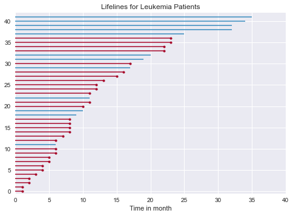

```python
durations = lk.t.values
events = lk.status.values

ax = lifelines.plotting.plot_lifetimes(durations=durations, event_observed=events)
ax.set_xlim(0, 40)
ax.set_xlabel("Time in month")
ax.set_title("Lifelines for Leukemia Patients")
plt.show()
```

## Estimate the survival function using Kaplan-Meier

Define survival function as $$\hat{S(t)}=\prod_{t_i<t}\frac{n_i-d_i}{n_i}$$ where $d_i$ is the number of death events at time $t$ and $n_i$ is the number of subjects at risk of death just prior to time $t$.

The KM estimate results in a step function that changes value only at the time of each event, and confidence intervals can be computed for the survival probabilities.

The KM survival curve, a plot of KM survival probability against time, provides a useful summary of the data. **It can be used to estimate measures such as median survival time**.

It CANNOT account for risk factors and is **NOT regression**. It is **non-parametric** (does not involve parameters).

However it is a good way to visualize a survival dataset, and can be useful to **compare the effects of a single categorical variable**.

### Population survival curve

```
Median Survival: 12.0 months after treatment
```

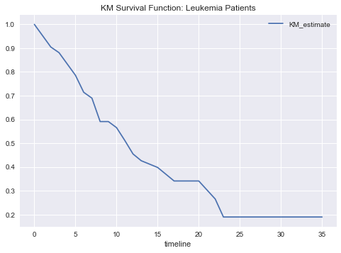

```python
kmf = lifelines.KaplanMeierFitter()
kmf.fit(durations, events)

kmf.survival_function_.plot()
plt.title('KM Survival Function: Leukemia Patients');
print('Median Survival: {} months after treatment'.format(kmf._median))
```

### Survival curves by treatment `Rx`

```
Median survival time with Treatment 1: 8.0 months
Median survival time with Treatment 0: 23.0 months
```

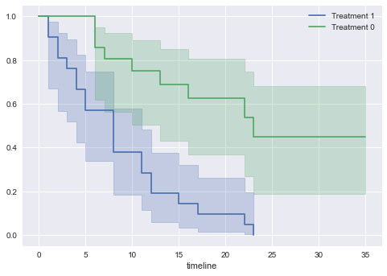

```python
ax = plt.subplot(111)

treatment = (lk['Rx']==1)

kmf.fit(durations[treatment], events[treatment], label = 'Treatment 1')
kmf.plot_survival_function(ax=ax)
print('Median survival time with Treatment 1: {} months'.format(kmf._median))

kmf.fit(durations[~treatment], events[~treatment], label = 'Treatment 0')
kmf.plot_survival_function(ax=ax)
print('Median survival time with Treatment 0: {} months'.format(kmf._median))
```

## Cox proportional hazards model (survival regression)

$$h(t|x)=b_0(t) exp(\sum_{i=1}^nb_i(x_i-\bar{x_i})$$

Useful for comparing relative hazards. It assumes the ratio of death event risks (hazard) of two groups remains about the same over time. This ratio is called the hazards ratio or the relative risk.

All Cox regression requires is an assumption that ratio of hazards is constant over time across groups.

```python
cph = lifelines.CoxPHFitter()
cph.fit(df=lk, duration_col='t', event_col='status')
cph.print_summary()
```

| model | lifelines.CoxPHFitter |
| --- | --- |
| duration col | 't' |
| event col | 'status' |
| baseline estimation | breslow |
| number of observations | 42 |
| number of events observed | 30 |
| partial log-likelihood | -69.59 |
| time fit was run | 2022-05-27 15:52:33 UTC |

|  | coef | exp(coef) | se(coef) | coef lower 95% | coef upper 95% | exp(coef) lower 95% | exp(coef) upper 95% | cmp to | z | p | -log2(p) |
| --- | --- | --- | --- | --- | --- | --- | --- | --- | --- | --- | --- |
| sex | 0.31 | 1.37 | 0.45 | -0.58 | 1.21 | 0.56 | 3.34 | 0.00 | 0.69 | 0.49 | 1.03 |
| logWBC | 1.68 | 5.38 | 0.34 | 1.02 | 2.34 | 2.78 | 10.40 | 0.00 | 5.00 | <0.005 | 20.71 |
| Rx | 1.50 | 4.50 | 0.46 | 0.60 | 2.41 | 1.82 | 11.11 | 0.00 | 3.26 | <0.005 | 9.80 |

| Concordance | 0.85 |
| --- | --- |
| Partial AIC | 145.18 |
| log-likelihood ratio test | 47.19 on 3 df |
| -log2(p) of ll-ratio test | 31.55 |

### Interpret the results

- `exp(coef)`: the estimated hazard ratio.
  - `Rx`: Participants who received treatment 1 had 4.5 times the hazard risk (risk of death) compared to those who received treatment 2.
  - `logWBC`: For every unit the `logWBC` increased, the hazard risk increased 5.38 times.
- `se(coef)`: standard error of the coefficient (used for calculating z-score and therefore p-value)
- `p`: describes statistical significance. It is the likelihood that the variable has no effect on the outcome
- `-log2(p)`: natural logarithm of p-value, used to more easily see differences in significance
- `lower/upper 0.95`: 95% confidence level. The output includes 95% CI for `coef` and 95% CI for `exp(coef)`
- `Concordance`: a measure of predictive power for classification problems (Here looking at the `status` column. A value from 0 to 1 where values above 0.6 are considered good fits, the higher the better)
- `log-likelihood ratio test`: this is a measure of how likely it is that the coefficients are not zero, and can compare the goodness of fit of a model versus an alternative null model.

### Plot the effect of varying a covariate

After fitting, we can plot **what the survival curves look like as we vary a single covariate while holding everything else equal**. This is useful to understand the impact of a covariate, given the model.

#### Continuous feature

Must bin with 'values' argument

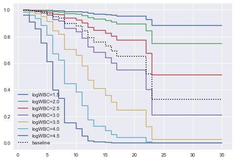

```python
cph.plot_covariate_groups(covariates='logWBC', values=np.arange(1.5,5,.5))
```

### Categorical feature

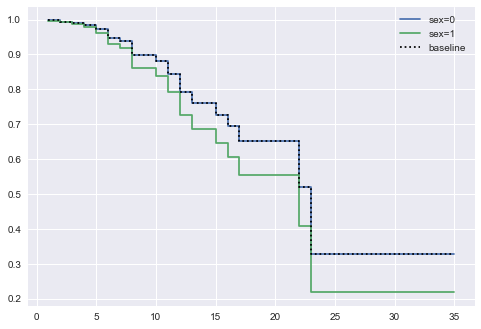

```python
cph.plot_covariate_groups(covariates='sex', values=[0,1]);
```

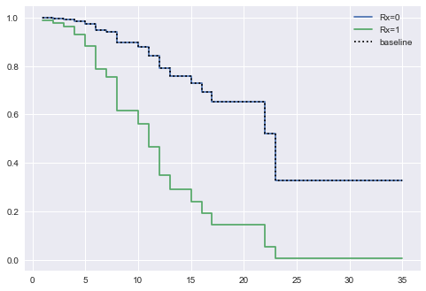

```python
# categorical feature
# is it the same as KM survival curve?
cph.plot_covariate_groups(covariates='Rx', values=[0,1])
```

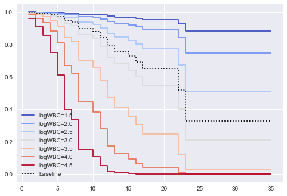

```python
# A different method
cph.plot_partial_effects_on_outcome(covariates='logWBC', values=np.arange(1.5,5,.5), cmap='coolwarm')
```

### Check the proportional hazards assumption

Assumption: the ratio of death events between groups remains constant over time.

```python
axes = cph.check_assumptions(lk, show_plots=True)
```

```
Proportional hazard assumption looks okay.
```

### Predict

Predict the survival function for individuals, given their covariates. This assumes that the individual just entered the study (that is, we do not condition on how long they have already lived for.)

```python
cph = lifelines.CoxPHFitter()
cph.fit(df=lk, duration_col='t', event_col='status')
```

```
<lifelines.CoxPHFitter: fitted with 42 total observations, 12 right-censored observations>
```

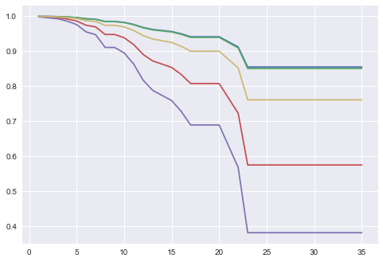

```python
surv_func = cph.predict_survival_function(lk[:5])

exp_lifetime = cph.predict_expectation(lk[:5])

plt.plot(surv_func)
plt.show()
```

No.3 has the least expected lifetime, and he/she has the largest hazard when the time arrives at the 35th month.

No.0 and No.1 have the longest expected lifetime, and they have the smallest hazard when the time arrives at the 35th month.

```python
exp_lifetime
```

```
0    31.483411
1    31.402901
2    26.371095
3    22.498885
4    29.813351
dtype: float64
```

```python
cph.predict_cumulative_hazard(lk[:5])
```

|  | 0 | 1 | 2 | 3 | 4 |
| --- | --- | --- | --- | --- | --- |
| 1.0 | 0.000321 | 0.000332 | 0.001134 | 0.001975 | 0.000559 |
| 2.0 | 0.000773 | 0.000800 | 0.002730 | 0.004756 | 0.001347 |
| 3.0 | 0.001234 | 0.001276 | 0.004355 | 0.007587 | 0.002149 |
| 4.0 | 0.002321 | 0.002400 | 0.008194 | 0.014275 | 0.004043 |
| 5.0 | 0.003966 | 0.004102 | 0.014003 | 0.024393 | 0.006909 |
| 6.0 | 0.007500 | 0.007756 | 0.026478 | 0.046125 | 0.013064 |
| 7.0 | 0.008859 | 0.009162 | 0.031277 | 0.054486 | 0.015433 |
| 8.0 | 0.015250 | 0.015771 | 0.053840 | 0.093790 | 0.026565 |
| 9.0 | 0.015250 | 0.015771 | 0.053840 | 0.093790 | 0.026565 |
| 10.0 | 0.018066 | 0.018684 | 0.063784 | 0.111112 | 0.031471 |
| 11.0 | 0.023952 | 0.024771 | 0.084563 | 0.147309 | 0.041724 |
| 12.0 | 0.032915 | 0.034041 | 0.116208 | 0.202435 | 0.057338 |
| 13.0 | 0.038786 | 0.040113 | 0.136937 | 0.238546 | 0.067566 |
| 15.0 | 0.044950 | 0.046488 | 0.158700 | 0.276458 | 0.078304 |
| 16.0 | 0.051684 | 0.053452 | 0.182473 | 0.317870 | 0.090034 |
| 17.0 | 0.060667 | 0.062743 | 0.214189 | 0.373121 | 0.105683 |
| 19.0 | 0.060667 | 0.062743 | 0.214189 | 0.373121 | 0.105683 |
| 20.0 | 0.060667 | 0.062743 | 0.214189 | 0.373121 | 0.105683 |
| 22.0 | 0.092208 | 0.095362 | 0.325544 | 0.567102 | 0.160627 |
| 23.0 | 0.157099 | 0.162473 | 0.554647 | 0.966201 | 0.273668 |
| 25.0 | 0.157099 | 0.162473 | 0.554647 | 0.966201 | 0.273668 |
| 32.0 | 0.157099 | 0.162473 | 0.554647 | 0.966201 | 0.273668 |
| 34.0 | 0.157099 | 0.162473 | 0.554647 | 0.966201 | 0.273668 |
| 35.0 | 0.157099 | 0.162473 | 0.554647 | 0.966201 | 0.273668 |

# Example 2: Recidivism

The data pertain to 432 convicts who were released from Maryland state prisons in the 1970s and who were followed up for one year after release. Half the released convicts were assigned at random to an experimental treatment in which they were given financial aid, half did not receive aid.

Let's see if they are re-arrested or not, and what factors affect it.

```python
from lifelines.datasets import load_rossi
rossi = load_rossi()

rossi.head()
```

|  | week | arrest | fin | age | race | wexp | mar | paro | prio |
| --- | --- | --- | --- | --- | --- | --- | --- | --- | --- |
| 0 | 20 | 1 | 0 | 27 | 1 | 0 | 0 | 1 | 3 |
| 1 | 17 | 1 | 0 | 18 | 1 | 0 | 0 | 1 | 8 |
| 2 | 25 | 1 | 0 | 19 | 0 | 1 | 0 | 1 | 13 |
| 3 | 52 | 0 | 1 | 23 | 1 | 1 | 1 | 1 | 1 |
| 4 | 52 | 0 | 0 | 19 | 0 | 1 | 0 | 1 | 3 |

The dataset contains 432 rows - each row represents one person.

`week` variable ranges from 1 to 52 - the study lasted for 52 weeks.

`arrest`, `fin`, `race`, `wexp`, `mar`, `paro` are binary variables.

```python
rossi.describe()
```

|  | week | arrest | fin | age | race | wexp | mar | paro | prio |
| --- | --- | --- | --- | --- | --- | --- | --- | --- | --- |
| count | 432.000000 | 432.000000 | 432.00000 | 432.000000 | 432.000000 | 432.000000 | 432.000000 | 432.000000 | 432.000000 |
| mean | 45.854167 | 0.263889 | 0.50000 | 24.597222 | 0.877315 | 0.571759 | 0.122685 | 0.618056 | 2.983796 |
| std | 12.662293 | 0.441251 | 0.50058 | 6.113375 | 0.328456 | 0.495398 | 0.328456 | 0.486426 | 2.896068 |
| min | 1.000000 | 0.000000 | 0.00000 | 17.000000 | 0.000000 | 0.000000 | 0.000000 | 0.000000 | 0.000000 |
| 25% | 50.000000 | 0.000000 | 0.00000 | 20.000000 | 1.000000 | 0.000000 | 0.000000 | 0.000000 | 1.000000 |
| 50% | 52.000000 | 0.000000 | 0.50000 | 23.000000 | 1.000000 | 1.000000 | 0.000000 | 1.000000 | 2.000000 |
| 75% | 52.000000 | 1.000000 | 1.00000 | 27.000000 | 1.000000 | 1.000000 | 0.000000 | 1.000000 | 4.000000 |
| max | 52.000000 | 1.000000 | 1.00000 | 44.000000 | 1.000000 | 1.000000 | 1.000000 | 1.000000 | 18.000000 |

```python
pd.DataFrame({'dtypes':rossi.dtypes,
              'nunique':rossi.nunique()})
```

|  | dtypes | nunique |
| --- | --- | --- |
| week | int64 | 49 |
| arrest | int64 | 2 |
| fin | int64 | 2 |
| age | int64 | 28 |
| race | int64 | 2 |
| wexp | int64 | 2 |
| mar | int64 | 2 |
| paro | int64 | 2 |
| prio | int64 | 17 |

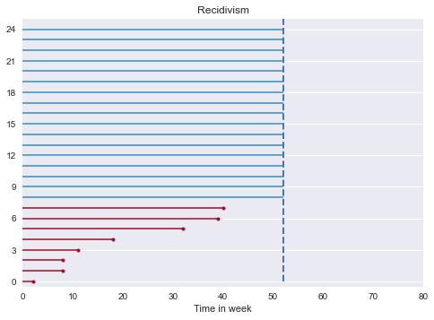

```python
# random sample 25 persons
rossi_sample = rossi.sample(n=25)

durations = rossi_sample.week.values
events = rossi_sample.arrest.values

ax = lifelines.plotting.plot_lifetimes(durations=durations, event_observed=events)
ax.set_xlim(0, 80)
ax.grid(axis='x')
ax.vlines(52, 0, 25, lw=2, linestyles='--')
ax.set_xlabel("Time in week")
ax.set_title("Recidivism")
plt.show()
```

## Estimate the survival function using Kaplan-Meier

### Population curve

```
Median Survival: inf weeks after release before re-arrested
```

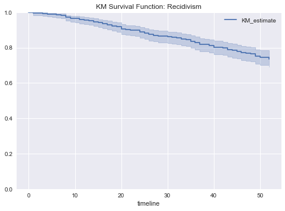

```python
kmf = lifelines.KaplanMeierFitter()

durations = rossi.week.values
events = rossi.arrest.values

kmf.fit(durations, events)

#kmf.survival_function_.plot()
kmf.plot()
plt.ylim(0,1)
plt.title('KM Survival Function: Recidivism')
print('Median Survival: {} weeks after release before re-arrested'.format(kmf._median))
```

Infinite median value: it happens when there are more than 50% data are censored, therefore the median is indetermined. For example, five years after treatment for a cancer, 60% of the initial cohort of 100 patients were still alive. What is their median survival time? All you know is it's greater than five years.

### Survival curve by financial aid

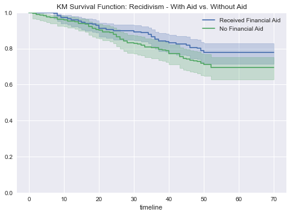

```python
kmf_aid = lifelines.KaplanMeierFitter()
kmf_no_aid = lifelines.KaplanMeierFitter()

aid = (rossi['fin']==1)
t = np.linspace(0, 70, 71)

kmf_aid.fit(durations[aid], events[aid], timeline=t, label="Received Financial Aid")
kmf_no_aid.fit(durations[~aid], events[~aid], timeline=t, label="No Financial Aid")

kmf_aid.plot()
kmf_no_aid.plot()

plt.ylim(0,1)
plt.title('KM Survival Function: Recidivism - With Aid vs. Without Aid')
plt.show()
```

## Estimate hazard rates using Nelson-Aalen

The survival functions is a great way to summarize and visualize the survival dataset, however it is not the only way. If we are curious about the hazard function $h(t)$ of a population, we unfortunately cannot transform the Kaplan Meier estimate – statistics doesn’t work quite that well. Fortunately, there is a proper non-parametric estimator of the cumulative hazard function: $$H(t)=\int_0^t\lambda(z)dz$$

The estimator for this quantity is called the Nelson Aalen estimator: $$\hat{H(t)}=\prod_{t_i<t}\frac{d_i}{n_i}$$ where $d_i$ is the number of death events at time $t$ and $n_i$ is the number of subjects at risk of death just prior to time $t$.

```
          NA_estimate
timeline
0.0          0.000000
1.0          0.002315
2.0          0.004635
3.0          0.006961
4.0          0.009292
```

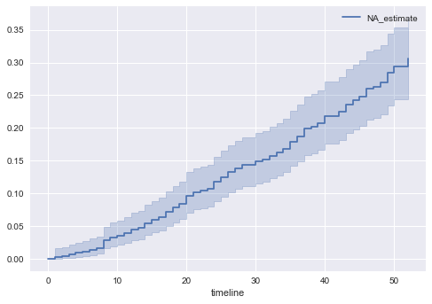

```python
naf = lifelines.NelsonAalenFitter()
naf.fit(durations, events)

print(naf.cumulative_hazard_.head())
naf.plot()
plt.show()
```

The cumulative hazard has less obvious understanding than the survival functions, but the hazard functions is the basis of more advanced techniques in survival analysis. Recall that we are estimating cumulative hazard functions, $H(t)$. (Why? The sum of estimates is much more stable than the point-wise estimates.) Thus we know **the rate of change** of this curve is an estimate of the hazard function.

Looking at figure above, it looks like the hazard starts off low and gets a little more higher (as seen by the steeper curve). Let’s seperate the persons by receiving financial aid or not.

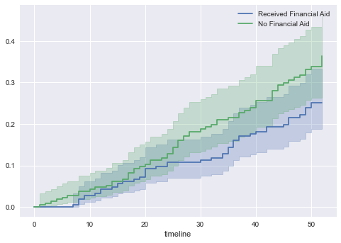

```python
naf_aid = lifelines.NelsonAalenFitter()
naf_no_aid = lifelines.NelsonAalenFitter()

naf_aid.fit(durations[aid], events[aid], label="Received Financial Aid")
naf_no_aid.fit(durations[~aid], events[~aid], label="No Financial Aid")

ax = naf_aid.plot_cumulative_hazard()
naf_no_aid.plot_cumulative_hazard(ax=ax)
plt.show()
```

Looking at the rate of change, people without financial aid have higher hazard rate, meaning that they are more prone to be re-arrested.

## Cox’s proportional hazard model

```python
cph = lifelines.CoxPHFitter()
cph.fit(rossi, duration_col='week',
        event_col='arrest', show_progress=True)
cph.print_summary()
```

```
Iteration 1: norm_delta = 0.50881, step_size = 0.9000, log_lik = -675.38063, newton_decrement = 16.76434, seconds_since_start = 0.0
Iteration 2: norm_delta = 0.14141, step_size = 0.9000, log_lik = -659.73483, newton_decrement = 0.93797, seconds_since_start = 0.0
Iteration 3: norm_delta = 0.02632, step_size = 0.9000, log_lik = -658.77431, newton_decrement = 0.02640, seconds_since_start = 0.0
Iteration 4: norm_delta = 0.00042, step_size = 1.0000, log_lik = -658.74767, newton_decrement = 0.00001, seconds_since_start = 0.0
Iteration 5: norm_delta = 0.00000, step_size = 1.0000, log_lik = -658.74766, newton_decrement = 0.00000, seconds_since_start = 0.0
Convergence success after 5 iterations.
```

| model | lifelines.CoxPHFitter |
| --- | --- |
| duration col | 'week' |
| event col | 'arrest' |
| baseline estimation | breslow |
| number of observations | 432 |
| number of events observed | 114 |
| partial log-likelihood | -658.75 |
| time fit was run | 2022-05-27 15:54:41 UTC |

|  | coef | exp(coef) | se(coef) | coef lower 95% | coef upper 95% | exp(coef) lower 95% | exp(coef) upper 95% | cmp to | z | p | -log2(p) |
| --- | --- | --- | --- | --- | --- | --- | --- | --- | --- | --- | --- |
| fin | -0.38 | 0.68 | 0.19 | -0.75 | -0.00 | 0.47 | 1.00 | 0.00 | -1.98 | 0.05 | 4.40 |
| age | -0.06 | 0.94 | 0.02 | -0.10 | -0.01 | 0.90 | 0.99 | 0.00 | -2.61 | 0.01 | 6.79 |
| race | 0.31 | 1.37 | 0.31 | -0.29 | 0.92 | 0.75 | 2.50 | 0.00 | 1.02 | 0.31 | 1.70 |
| wexp | -0.15 | 0.86 | 0.21 | -0.57 | 0.27 | 0.57 | 1.30 | 0.00 | -0.71 | 0.48 | 1.06 |
| mar | -0.43 | 0.65 | 0.38 | -1.18 | 0.31 | 0.31 | 1.37 | 0.00 | -1.14 | 0.26 | 1.97 |
| paro | -0.08 | 0.92 | 0.20 | -0.47 | 0.30 | 0.63 | 1.35 | 0.00 | -0.43 | 0.66 | 0.59 |
| prio | 0.09 | 1.10 | 0.03 | 0.04 | 0.15 | 1.04 | 1.16 | 0.00 | 3.19 | <0.005 | 9.48 |

| Concordance | 0.64 |
| --- | --- |
| Partial AIC | 1331.50 |
| log-likelihood ratio test | 33.27 on 7 df |
| -log2(p) of ll-ratio test | 15.37 |

```python
# Use formula to handle the right-hand-side of the linear model
# Formulas can be used to create interactions, encode categorical variables, create basis splines, and so on.
cph.fit(rossi, duration_col='week', event_col='arrest', formula="fin + wexp + age * prio")
cph.print_summary()
```

| model | lifelines.CoxPHFitter |
| --- | --- |
| duration col | 'week' |
| event col | 'arrest' |
| baseline estimation | breslow |
| number of observations | 432 |
| number of events observed | 114 |
| partial log-likelihood | -659.39 |
| time fit was run | 2022-05-27 15:54:45 UTC |

|  | coef | exp(coef) | se(coef) | coef lower 95% | coef upper 95% | exp(coef) lower 95% | exp(coef) upper 95% | cmp to | z | p | -log2(p) |
| --- | --- | --- | --- | --- | --- | --- | --- | --- | --- | --- | --- |
| age | -0.03 | 0.97 | 0.03 | -0.09 | 0.03 | 0.92 | 1.03 | 0.00 | -0.93 | 0.35 | 1.51 |
| fin | -0.33 | 0.72 | 0.19 | -0.70 | 0.04 | 0.49 | 1.05 | 0.00 | -1.73 | 0.08 | 3.57 |
| prio | 0.31 | 1.36 | 0.17 | -0.03 | 0.64 | 0.97 | 1.90 | 0.00 | 1.80 | 0.07 | 3.80 |
| wexp | -0.24 | 0.79 | 0.21 | -0.65 | 0.17 | 0.52 | 1.19 | 0.00 | -1.14 | 0.26 | 1.97 |
| age:prio | -0.01 | 0.99 | 0.01 | -0.02 | 0.01 | 0.98 | 1.01 | 0.00 | -1.28 | 0.20 | 2.32 |

| Concordance | 0.64 |
| --- | --- |
| Partial AIC | 1328.77 |
| log-likelihood ratio test | 31.99 on 5 df |
| -log2(p) of ll-ratio test | 17.35 |

Back to the original cph model:

```python
cph.fit(rossi, duration_col='week', event_col='arrest')
cph.print_summary()
```

| model | lifelines.CoxPHFitter |
| --- | --- |
| duration col | 'week' |
| event col | 'arrest' |
| baseline estimation | breslow |
| number of observations | 432 |
| number of events observed | 114 |
| partial log-likelihood | -658.75 |
| time fit was run | 2022-05-27 15:54:49 UTC |

|  | coef | exp(coef) | se(coef) | coef lower 95% | coef upper 95% | exp(coef) lower 95% | exp(coef) upper 95% | cmp to | z | p | -log2(p) |
| --- | --- | --- | --- | --- | --- | --- | --- | --- | --- | --- | --- |
| fin | -0.38 | 0.68 | 0.19 | -0.75 | -0.00 | 0.47 | 1.00 | 0.00 | -1.98 | 0.05 | 4.40 |
| age | -0.06 | 0.94 | 0.02 | -0.10 | -0.01 | 0.90 | 0.99 | 0.00 | -2.61 | 0.01 | 6.79 |
| race | 0.31 | 1.37 | 0.31 | -0.29 | 0.92 | 0.75 | 2.50 | 0.00 | 1.02 | 0.31 | 1.70 |
| wexp | -0.15 | 0.86 | 0.21 | -0.57 | 0.27 | 0.57 | 1.30 | 0.00 | -0.71 | 0.48 | 1.06 |
| mar | -0.43 | 0.65 | 0.38 | -1.18 | 0.31 | 0.31 | 1.37 | 0.00 | -1.14 | 0.26 | 1.97 |
| paro | -0.08 | 0.92 | 0.20 | -0.47 | 0.30 | 0.63 | 1.35 | 0.00 | -0.43 | 0.66 | 0.59 |
| prio | 0.09 | 1.10 | 0.03 | 0.04 | 0.15 | 1.04 | 1.16 | 0.00 | 3.19 | <0.005 | 9.48 |

| Concordance | 0.64 |
| --- | --- |
| Partial AIC | 1331.50 |
| log-likelihood ratio test | 33.27 on 7 df |
| -log2(p) of ll-ratio test | 15.37 |

Take a look at these coefficients:

- `prio` (the number of prior arrests) has a coefficient of about 0.09. Thus, a one unit increase in `prio` means the the baseline hazard will increase by a factor of $exp(0.09)=1.10$ - about a 10% increase. Recall, in the Cox proportional hazard model, a higher hazard means more at risk of the event occurring. The value $exp(0.09)$ is called the hazard ratio.
- `mar` (whether the subject is married or not). The values in the column are binary: 0 or 1, representing either unmarried or married. The value of the coefficient associated with `mar`, $exp(−0.43)$, is the value of ratio of hazards associated with being married. Getting married will reduce the hazard by $exp(-0.43)=0.65$ - about a 35% decrease.

`race`, `paro`, `wexp`, `mar` are not significant.

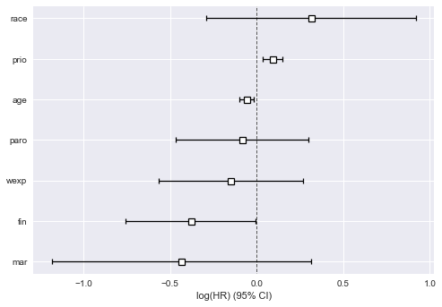

```python
cph.plot()
plt.show()
```

### Plot the effect of varying a covariate

Holding other variable fixed, receving financial aid increases the "survival probability" (i.e., not be re-arrested).

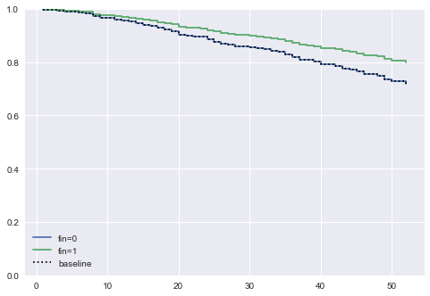

```python
cph.plot_covariate_groups('fin', [0, 1])
plt.ylim(0,1)
plt.show()
```

Holding other variable fixed, people with less number of prior arrest have larger "survival probability".

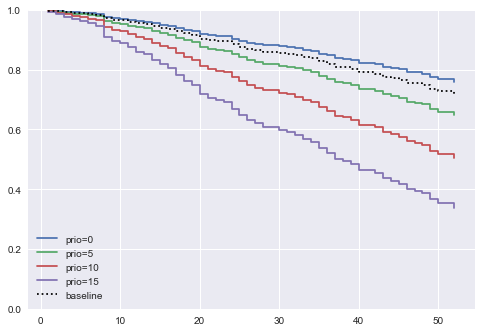

```python
cph.plot_covariate_groups('prio', [0, 5, 10, 15])
plt.ylim(0,1)
plt.show()
```

If the regression has specified righ-hand-side, the plot is made by automatically varying `prio` and `prio**2` while fixing others:

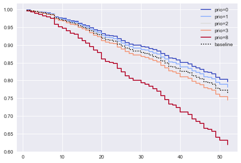

```python
cph.fit(rossi, 'week', 'arrest', formula="prio + I(prio**2)")

cph.plot_partial_effects_on_outcome(
    covariates=['prio'],
    values=[0, 1, 2, 3, 8],
    cmap='coolwarm')
```

### Check assumption

```
The ``p_value_threshold`` is set at 0.01. Even under the null hypothesis of no violations, some
covariates will be below the threshold by chance. This is compounded when there are many covariates.
Similarly, when there are lots of observations, even minor deviances from the proportional hazard
assumption will be flagged.

With that in mind, it's best to use a combination of statistical tests and visual tests to determine
the most serious violations. Produce visual plots using ``check_assumptions(..., show_plots=True)``
and looking for non-constant lines. See link [A] below for a full example.
```

| null_distribution | chi squared |
| --- | --- |
| degrees_of_freedom | 1 |
| model | <lifelines.CoxPHFitter: fitted with 432 total ... |
| test_name | proportional_hazard_test |

|  |  | test_statistic | p | -log2(p) |
| --- | --- | --- | --- | --- |
| age | km | 11.03 | <0.005 | 10.12 |
|  | rank | 11.45 | <0.005 | 10.45 |
| fin | km | 0.02 | 0.89 | 0.17 |
|  | rank | 0.02 | 0.90 | 0.15 |
| mar | km | 0.60 | 0.44 | 1.19 |
|  | rank | 0.71 | 0.40 | 1.32 |
| paro | km | 0.12 | 0.73 | 0.45 |
|  | rank | 0.13 | 0.71 | 0.49 |
| prio | km | 0.02 | 0.88 | 0.18 |
|  | rank | 0.02 | 0.89 | 0.17 |
| race | km | 1.44 | 0.23 | 2.12 |
|  | rank | 1.43 | 0.23 | 2.11 |
| wexp | km | 7.48 | 0.01 | 7.32 |
|  | rank | 7.31 | 0.01 | 7.19 |

```
1. Variable 'age' failed the non-proportional test: p-value is 0.0007.

   Advice 1: the functional form of the variable 'age' might be incorrect. That is, there may be
non-linear terms missing. The proportional hazard test used is very sensitive to incorrect
functional forms. See documentation in link [D] below on how to specify a functional form.

   Advice 2: try binning the variable 'age' using pd.cut, and then specify it in `strata=['age',
...]` in the call in `.fit`. See documentation in link [B] below.

   Advice 3: try adding an interaction term with your time variable. See documentation in link [C]
below.


   Bootstrapping lowess lines. May take a moment...


2. Variable 'wexp' failed the non-proportional test: p-value is 0.0063.

   Advice: with so few unique values (only 2), you can include `strata=['wexp', ...]` in the call in
`.fit`. See documentation in link [E] below.

   Bootstrapping lowess lines. May take a moment...


---
[A]  https://lifelines.readthedocs.io/en/latest/jupyter_notebooks/Proportional%20hazard%20assumption.html
[B]  https://lifelines.readthedocs.io/en/latest/jupyter_notebooks/Proportional%20hazard%20assumption.html#Bin-variable-and-stratify-on-it
[C]  https://lifelines.readthedocs.io/en/latest/jupyter_notebooks/Proportional%20hazard%20assumption.html#Introduce-time-varying-covariates
[D]  https://lifelines.readthedocs.io/en/latest/jupyter_notebooks/Proportional%20hazard%20assumption.html#Modify-the-functional-form
[E]  https://lifelines.readthedocs.io/en/latest/jupyter_notebooks/Proportional%20hazard%20assumption.html#Stratification
```

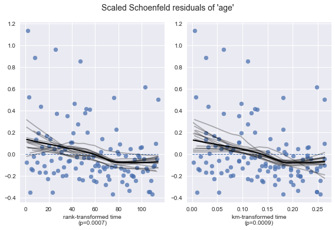

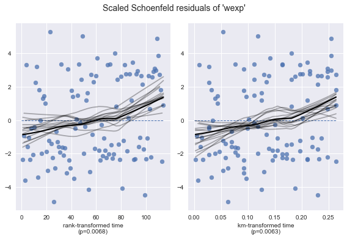

```python
cph.fit(rossi, duration_col='week', event_col='arrest')
cph.check_assumptions(rossi, show_plots=True)
plt.show()
```

#### Stratification

Sometimes one or more covariates may not obey the proportional hazard assumption. In this case, we can allow the covariate(s) to still be including in the model **without estimating its effect**. This is called stratification.

At a high level, think of it as splitting the dataset into m smaller datasets, partitioned by the unique values of the stratifying covariate(s). Each dataset has its own baseline hazard (the non-parametric part of the model), but they all share the regression parameters (the parametric part of the model). Since covariates are the same within each dataset, there is no regression parameter for the covariates stratified on, hence they will not show up in the output. However there will be **m baseline hazards** under `baseline_cumulative_hazard_`.

```python
cph = lifelines.CoxPHFitter()
cph.fit(rossi, 'week', event_col='arrest', strata=['wexp','age'])
cph.print_summary()
```

| model | lifelines.CoxPHFitter |
| --- | --- |
| duration col | 'week' |
| event col | 'arrest' |
| strata | [wexp, age] |
| baseline estimation | breslow |
| number of observations | 432 |
| number of events observed | 114 |
| partial log-likelihood | -276.39 |
| time fit was run | 2022-05-27 15:57:14 UTC |

|  | coef | exp(coef) | se(coef) | coef lower 95% | coef upper 95% | exp(coef) lower 95% | exp(coef) upper 95% | cmp to | z | p | -log2(p) |
| --- | --- | --- | --- | --- | --- | --- | --- | --- | --- | --- | --- |
| fin | -0.32 | 0.73 | 0.20 | -0.71 | 0.08 | 0.49 | 1.08 | 0.00 | -1.57 | 0.12 | 3.09 |
| race | -0.04 | 0.96 | 0.33 | -0.68 | 0.60 | 0.51 | 1.83 | 0.00 | -0.11 | 0.91 | 0.14 |
| mar | -0.20 | 0.82 | 0.41 | -1.01 | 0.61 | 0.37 | 1.84 | 0.00 | -0.48 | 0.63 | 0.67 |
| paro | -0.06 | 0.94 | 0.21 | -0.47 | 0.36 | 0.62 | 1.43 | 0.00 | -0.28 | 0.78 | 0.35 |
| prio | 0.09 | 1.10 | 0.03 | 0.03 | 0.16 | 1.03 | 1.17 | 0.00 | 2.77 | 0.01 | 7.48 |

| Concordance | 0.58 |
| --- | --- |
| Partial AIC | 562.78 |
| log-likelihood ratio test | 11.08 on 5 df |
| -log2(p) of ll-ratio test | 4.33 |

```python
len(np.unique(rossi[['wexp','age']], axis=0))
```

```
49
```

```python
# (wexp, age) has 49 unique values
cph.baseline_survival_.shape
```

```
(49, 49)
```

```python
cph.check_assumptions(rossi, show_plots=True)
plt.show()
```

```
Proportional hazard assumption looks okay.
```

# Resources

- https://github.com/chrisluedtke/data-science-journal/blob/master/07-Advanced-Regression/02_Survival_Analysis.ipynb
- https://lifelines.readthedocs.io/en/latest/index.html